# Motor Trend Analysis

Morozov Gleb

Sunday, May 24, 2015

## Executive Summary

Do cars with manual transmission behave more favorably than automatic transmission cars with respect to fuel efficiency? It is a common belief that changing gears manually results in better fuel management To do this analysis we will use a data set that examines the fuel efficency and 10 aspects of automobile design and performance for 32 automobiles (all 1973 - 1974 models). Out of the 32 cars, 13 have manual transmissions and 19 have automatic transmissions.

In this data set on average there is a difference in fuel efficency depending on transmission type such that on average manual vehicles achieve a fuel effiency of 7.2 miles per gallon more than automatic vehicles.

However, transmission type is not a particularly good predictor of fuel efficiency. By applying analysis of variance (ANOVA) to the dataset, and building a number of models, we were able to identify that the number of cylinders and the weight of the automobile are good predictors of fuel efficiency, achieving an adjusted R squared of 0.82. If we add transmission type to this model, then the difference in fuel effiency for a manual transmission is much smaller, just 0.18 miles per gallon for a vehicle with the same weight and number of cylinders.

Therefore we conclude that number of cylinders and weight are good predictors of fuel efficiency, but transmission type is not.

## The data set

```r
library(ggplot2)
library(datasets)
data(mtcars)
attach(mtcars)
```

```r
str(mtcars)
```

```
## 'data.frame':    32 obs. of  11 variables:
##  $ mpg : num  21 21 22.8 21.4 18.7 18.1 14.3 24.4 22.8 19.2 ...
##  $ cyl : num  6 6 4 6 8 6 8 4 4 6 ...
##  $ disp: num  160 160 108 258 360 ...
##  $ hp  : num  110 110 93 110 175 105 245 62 95 123 ...
##  $ drat: num  3.9 3.9 3.85 3.08 3.15 2.76 3.21 3.69 3.92 3.92 ...
##  $ wt  : num  2.62 2.88 2.32 3.21 3.44 ...
##  $ qsec: num  16.5 17 18.6 19.4 17 ...
##  $ vs  : num  0 0 1 1 0 1 0 1 1 1 ...
##  $ am  : num  1 1 1 0 0 0 0 0 0 0 ...
##  $ gear: num  4 4 4 3 3 3 3 4 4 4 ...
##  $ carb: num  4 4 1 1 2 1 4 2 2 4 ...
```

The data set was extracted from the 1974 edition of Motor Trend US Magazine and it deals with 1973 - 1974 models. It consists of 32 observations on 11 variables:

- `mpg`: Miles per US gallon
- `cyl`: Number of cylinders
- `disp`: Displacement (cubic inches)
- `hp`: Gross horsepower
- `drat`: Rear axle ratio
- `wt`: Weight (lb / 1000)
- `qsec`: 1 / 4 mile time
- `vs`: V/S
- `am`: Transmission (0 = automatic, 1 = manual)
- `gear`: Number of forward gears
- `carb`: Number of carburetors

Here we see that our predictor variable of interest, `am`, is a numeric class. Since we are dealing with a dichotomous variable, let’s convert this to a factor class and label the levels as `Automatic` and `Manual` for better interpretability.

```r
mtcars$am <- as.factor(mtcars$am)
levels(mtcars$am) <- c("Automatic", "Manual")
mtcars$cyl <- factor(mtcars$cyl)
mtcars$vs <- factor(mtcars$vs)
mtcars$gear <- factor(mtcars$gear)
mtcars$carb <- factor(mtcars$carb)
```

## Exploratory Data Analysis

Since we will be running a linear regression, we want to make sure that its assumptions are met. Let’s plot the dependent variable `mpg` to check its distribution.

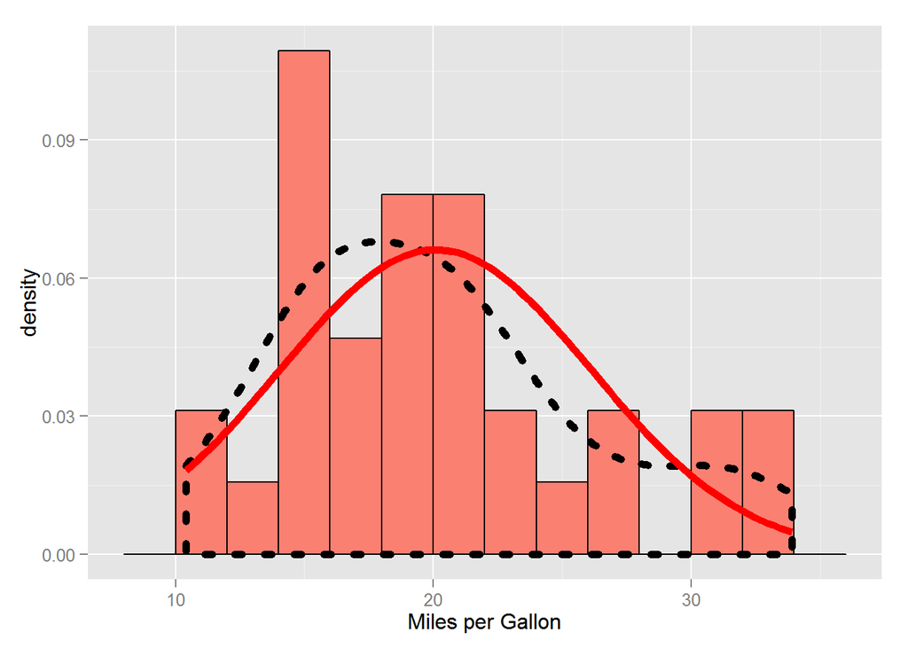

```r
ggplot(mtcars, aes(x = mpg)) +
        geom_histogram(binwidth = 2, colour = "black", fill ="salmon",
                       aes(y = ..density..)) +
        geom_density(size = 2, colour = "black", linetype = "dotted") +
        stat_function(fun = dnorm, colour = "red",
                      size = 2, arg = list(mean=mean(mpg), sd= sd(mpg))) +
        labs(x = "Miles per Gallon")
```

We want to know if our sample for `mpg` is from normaly distributed population. The test result depends on p-value. When p < 0.05, then population is likely not normaly distributed. When p > 0.05 there is no such evidence.

```r
shapiro.test(mtcars$mpg)
```

```
##
##  Shapiro-Wilk normality test
##
## data:  mtcars$mpg
## W = 0.94756, p-value = 0.1229
```

Plot and large p-value indicates that population of `mpg` is likely to be normaly distributed. Now let’s check how `mpg` varies by automatic versus manual transmission.

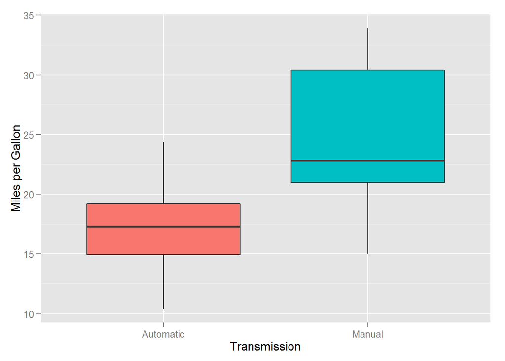

```r
ggplot(mtcars, aes(x = am, y=mpg)) + geom_boxplot(aes(fill = am)) +
        labs(x = "Transmission", y = "Miles per Gallon") + guides(fill=F)
```

We want to know if there is any difference at all, in fuel consumption for two types of transmision. Again, p-value will provide an answer. p < 0.05 indicates that means are likely different. p > 0.05 provides no such evidence.

```r
t.test(mtcars$mpg ~ mtcars$am)
```

```
##
##  Welch Two Sample t-test
##
## data:  mtcars$mpg by mtcars$am
## t = -3.7671, df = 18.332, p-value = 0.001374
## alternative hypothesis: true difference in means is not equal to 0
## 95 percent confidence interval:
##  -11.280194  -3.209684
## sample estimates:
## mean in group Automatic    mean in group Manual
##                17.14737                24.39231
```

Low p-value indicates difference for these two groups. Also the numbers representing the mean fuel consumption for manual and automatic type clearly are diffrent.